# Econometria Aplicada à Finanças Aula 7

Mestrado Profissional em Administração

Prof. Washington Santos da Silva

IFMG - Campus Formiga

30 de setembro de 2025

## Diário de Bordo

**O que vimos até o momento?**

- Aula 1 ✅
  - Apresentação da Disciplina ✅
  - Introdução ao RStudio ✅
  - Configurando o Projeto da Disciplina ✅
  - Conheça e Utilize o Terminal Git Bash ✅
- Aula 2 ✅
  - Git e GitHub: Visão Geral ✅
  - Introdução ao Sistema: Visão Geral ✅
  - Linguagem R: Visão Geral ✅
  - Sessão Prática 1 ✅
- Aula 3 ✅
  - Minicurso Intensivo: Teoria da Probabilidade - Parte 1 ✅
    - Introdução à Teoria da Probabilidade ✅
    - Variáveis Aleatórias e Distribuições de Probabilidade ✅
    - Distribuições Conjunta, Marginal e Condicional ✅
    - Independência de Variáveis Aleatórias ✅
- Aula 4 ✅
  - Minicurso Intensivo: Teoria da Probabilidade - Parte 2 ✅
    - Conceitos Básicos: Revisão ✅
    - Momentos de Distribuições de Probabilidade Univariadas ✅
    - Funções de Variáveis Aleatórias ✅
    - Fundamentos de Distribuições de Probabilidade Multivariadas ✅
    - Cálculo Diferencial e Integral em R
- Aula 5 ✅
  - Minicurso Intensivo: Teoria da Probabilidade - Parte 3 ✅
  - Distribuições de Variáveis Aleatórias Discretas ✅
  - Distribuições de Variáveis Aleatórias Contínuas ✅
  - Distribuições de Vetores Aleatórios ✅
  - A Ponte entre Probabilidade e Estatística/Econometria ✅
- Aula 6 ✅
  - Minicurso Intensivo: Métodos de Inferência Estatística I ✅
  - Estimação de Parâmetros: O Básico ✅
  - Métodos de Estimação de Parâmetros ✅
  - Estimação pode Intervalos de Confiança ✅

## Nesta Aula

**Minicurso Intensivo: Métodos de Inferência Estatística II**

- Propriedades dos Estimadores de Máxima Verossimilhança
- Testes de Hipóteses (ou de Significância)
- Fim do Minicurso

**Diretrizes para Aulas Mais Produtivas**

⌨️ **Código com método:**

95% dos erros são evitáveis com:

- Respeitar a sequência lógica de etapas
- Revisão antes de pedir ajuda
- Atenção na digitação

🤝 **Inteligência colaborativa:**

- Compartilhe conhecimento
- Resolva questões técnicas simples com colegas próximos
- Reserve ao professor as dúvidas conceituais complexas

💪 **Capacidade de Resolver Problemas**

Cada problema/erro resolvido é uma evolução da sua habilidade analítica

# Propriedades dos Estimadores de Máxima Verossimilhança

## Estimadores de Máxima Verossimilhança

**Propriedades**

#### **Consistência**

Os EMV são **consistentes**, isto é, $\hat\theta \xrightarrow{p} \theta$ quando $n \to \infty$.

#### **Normalidade Assintótica**

- Sob condições regulares, os EMV tem distribuição assintóticamente normal:
  $$\sqrt{n}\,(\hat\theta - \theta) \;\overset{d}{\longrightarrow}\; N\!\left(0, I^{-1}(\theta)\right),$$

  onde $I(\theta)$ é a **informação de Fisher**.
- Permite construir intervalos de confiança e testes de hipótese **assintóticos** baseados na aproximação normal.

#### **Eficiência Assintótica**

- Os EVM atingem, assintoticamente, o **limite de Cramér–Rao**, tendo a menor variância entre os estimadores consitentes.
- Interpretação: em grandes amostras, é o estimador mais preciso.

#### **Invariância**

- Os EMV são invariantes a **transformações** do parâmetro.
- Se $\hat\theta$ é o EVM de $\theta$, então $g(\hat\theta)$ é o EVM de $g(\theta)$ para qualquer função $g$ monotônica.
- Exemplo: se o parâmetro de interesse é $\sigma^2$, e o EVM é $\hat\sigma^2$, então o EVM para $\sigma$ é $\hat\sigma = \sqrt{\hat\sigma^2}$.

## Estimadores de Máxima Verossimilhança

**Nada é perfeito**

- Consistência, normalidade assintótica, eficiência no sentido de Cramér-Ra e invariância são argumentos fortes em favor dos EMV.
- Entretanto, eles podem apresentar problemas:
1. Eles podem ser **viesados** [**vimos um exemplo**](https://washingtonsilva.github.io/blog/02-post/02-post.html) (pelos menos em amostras pequenas)
2. Eles podem ser [**difíceis de derivar**](https://washingtonsilva.github.io/blog/02-post/02-post.html) e/ou calcular.
3. Eles podem ser **sensíveis à especificação incorreta** da **distribuição de probabilidade** subjacente.
- Em econometria, encontramos estimadores derivados tanto pelo método dos momentos quanto pelo método da máxima verossimilhança.
- Alguns estimadores são os mesmos pelos dois métodos.
- Não há resposta unformemente correta sobre qual método é preferível ou melhor - o contexto é importante - mas temos ferramentas para avaliar diferentes estimadores em um contexto particular.

# Teste de Hipóteses

## Introdução

**Onde estamos?**

- Bem, agora sabemos o que é um **estimador**;
- Como **estimar parâmetros desconhecidos**: método dos momentos e método da máxima verossimilhança;
- E algumas formas diferentes de expressar **o quão confiantes** estamos em nossas estimativas: erros-padrão e intervalos de confiança para estimativas de parâmetros;
- Isso nos leva longe e nos dá uma boa base para estudar todos os tipos de estimadores daqui para frente.
- Mas precisamos de mais um tópico fundacional importante: **testes de hipóteses** (ou de significância).

## Teste de Hipóteses

**Motivação**

- Nas ciências sociais (assim como nas demais áreas do conhecimento), toda pesquisa começa com uma pergunta relevante.
- Alguns de vocês já começaram a formular perguntas para o seu projeto de dissertação.
- Testes estatísticos de hipóteses ajudam a respondê-las com evidências baseadas em dados.
- Profissionais e pesquisadores de diversas áreas fazem uso extensivo de **testes estatísticos de hipóteses**, também denominados **testes de significância**.
- Permitem avaliar a **validade de hipóteses científicas**, modelos e suposições.

## Hipóteses Científicas “Estatísticas”

**Exemplos**

- O **retorno médio** de fundos ativos é maior que o retorno médio das carteiras passivas no mercado financeiro brasileiro?
- A **rentabilidade média** sobre o ativo (ROA) das cooperativas de crédito que adotaram práticas recomendadas de governança corporativa é maior do que a rentabilidade média das cooperativas que não adotaram tais práticas?
- A **taxa média de juros efetiva** obtida por empresas do agronegócio brasileiro que reportam indicadores de desempenho ambiental (ESG) é significativamente menor do que a taxa média de juros das empresas do setor que não reportam tais indicadores?

## Teste de Hipóteses

**Exemplos de Hipóteses (Estatísticas) “Profissionais”**

Mas esses testes não servem somente à pesquisa científica:

- Um **analista financeiro** pode testar, com base em dados, se a proporção média de clientes inadimplentes de uma instituição financeira, diminuiu após a implementação de uma nova política de crédito em comparação com o período anterior.
- Um **analista de marketing digital** pode testar, com base em dados, se a taxa média de cliques ou conversões na população de destinatários foi maior com o novo layout de e-mail do que com o layout anterior.
- Esses exemplos mostram que, quando queremos saber se uma mudança realmente fez diferença — e não foi apenas devida ao acaso — podemos aplicar um teste de hipótese.
- Esse tipo de raciocínio orienta decisões críticas em finanças, marketing, gestão pública e em muitas outras áreas.”

## Teste de Hipóteses

**Visão Geral**

- A ferramenta que os estatísticos inventaram para ajudar a responder a essas perguntas é o teste de hipóteses.
- Em estatística/econometria, uma hipótese é uma **afirmação** sobre um **parâmetro populacional**.
- Isto é, é uma afirmação sobre uma característica (como média, proporção) da **distribuição** de probabilidade que rege a **variável aleatória** de interesse.
- A hipótese assume a forma de uma **previsão sobre o valor de um parâmetro** (ou sobre a relação entre parâmetros) **da distribuição da variável aleatória** de interesse que pode ser testada com base em dados amostrais.
- Em geral, as hipóteses são derivadas de teorias ou modelos econômicos e financeiros.

## Teste de Hipóteses

**Contexto**

- Há um vetor aleatório $X$ que tem uma distribuição $F(x)$.
- O interesse se concentra em um parâmetro de interesse real (escalar) $\theta$ determinado por $F \in \mathbb{F}$, sendo $\mathbb{F}$ uma família de distribuições de probabilidade.
- O espaço paramétrico de $\theta$ é $\Theta$.
- Os testes de hipóteses serão construídos a partir de uma amostra aleatória $\{X_1,\ldots,X_n\}$ da distribuição F.

## Teste de Hipóteses

**Definição: Valor Hipotético**

Uma hipótese pontual é a afirmação de que $\theta$ é igual a um valor específico $\theta_0$, denominado *valor hipotético*.

O valor hipotético é aquele implícito em uma teoria ou hipótese.

#### Exemplo 1

Um exemplo comum surge quando $\theta$ mede o efeito de uma política proposta.

Uma pergunta típica é se o efeito é zero ou não.

Isso pode ser respondido testando a hipótese de que a política não tem efeito.

Isto é equivalente à afirmação de que $\theta = 0$.

Essa hipótese é representada pelo valor $\theta_0 = 0$.

#### Exemplo 2

Outro exemplo comum é quando $\theta$ representa a diferença em uma característica média ou escolha entre grupos.

A hipótese de que não há diferença média entre os grupos é a afirmação de que $\theta = 0$.

Essa hipótese é $\theta = \theta_0$ com $\theta_0 = 0$.

## Teste de Hipóteses

**Definição: Hipótese Nula ($H_0$)**

Chamamos a hipótese a ser testada de **hipótese nula**.

Frequentemente assume a forma de **igualdade**:

$H_0: \theta = \theta_0$

É a hipótese que representa **ausência de efeito**, **ausência de diferença**, **ausência de associação ou correlação**, etc.

## Teste de Hipóteses

**Definição: Hipótese Alternativa ($H_A$ ou $H_1$)**

O complemento da hipótese nula (o conjunto de valores de parâmetros que não satisfazem a hipótese nula) é chamado de **hipótese alternativa**.

As hipóteses alternativas podem ser:

- **bilaterais:** $H_A: \theta \neq \theta_0$
- **unilaterais:** $H_A: \theta > \theta_0$ ou $H_A: \theta < \theta_0$

É a hipótese que representa **presença** do efeito, da associação ou diferença que se deseja investigar.

**Nota:** Hipóteses alternativas bilaterais são mais comuns nas aplicações do que as unilaterais, mas as unilaterais são mais simples de analisar.

## Teste de Hipóteses

**Contexto e Objetivo**

- Em um teste de hipóteses, assumimos que existe um valor verdadeiro, porém desconhecido, de $\theta$ que satisfaz $H_0$ ou não satisfaz $H_0$.
- O objetivo do teste é avaliar se $H_0$ é verdadeira ou não, examinando os dados observados.
- Ilustramos com dois exemplos.

## Teste de Hipóteses

**Exemplo 1: Programa de Educação Infantil**

- Impacto de um programa de educação infantil sobre os rendimentos salariais de adultos.
- Queremos saber se a participação no programa na infância aumenta os salários anos depois, na idade adulta.
- Seja $\theta$ a diferença nos **salários médios** entre as populações de indivíduos que participaram do programa ($W_1$) versus indivíduos que não participaram ($W_2$), $\theta = W_1 - W_2$.
- A hipótese nula é que o programa não tem efeito sobre os salários médios, então $H_0: \theta = 0$.
- A hipótese alternativa é que o programa aumenta os salários médios, então a alternativa é unilateral $H_A: \theta > 0$.

## Teste de Hipóteses

**Exemplo 2: Rotas de Ônibus**

- Suponha que existam duas rotas de ônibus da sua casa até o trabalho: o ônibus 1 e o ônibus 2.
- Você deseja saber qual deles é, em média, mais rápido.
- Defina $\theta$ como a diferença entre os tempos médios de viagem do ônibus 1 e do ônibus 2.
- Um ponto de partida razoável é a hipótese de que os dois ônibus levam o mesmo tempo em média. Definimos isso como a **hipótese nula**, ou seja, $H_0: \theta_0 = 0$.
- A **hipótese alternativa** é que as duas rotas possuem tempos médios de viagem diferentes, isto é, a hipótese bilateral $H_1 : \theta \neq 0.$

## Teste de Hipóteses

**Definição: Hipóteses Simples e Composta**

- Podemos ver que uma **hipótese** é uma restrição sobre a distribuição $F$ dos dados, por exemplo, $H_0: \theta = \theta_0$.
- Seja $F_0$ a distribuição de $X$ sob a hipótese nula $H_0$, ou seja, sob a suposição de que a $H_0$ é verdadeira.
- Dependendo de como essa restrição é feita, podemos ter diferentes situações:
- Uma **única distribuição** que descreve completamente os dados.
- Uma **família de distribuições**, ainda com algum parâmetro livre (desconhecido).
- Ou até uma **família não paramétrica**, mais ampla e menos restrita.

**Exemplos:**

- **Distribuição única:** Se $X \sim N(\theta, \sigma^2)$ e $\sigma^2$ é conhecida, e $H_0: \theta = 2$, então $F_0 = \{N(2, \sigma^2)\}$ (um único modelo).
- **Família paramétrica:** Se $X \sim N(\theta, \sigma^2)$ e $\sigma^2$ é desconhecida e $H_0: \theta = 0$, então $F_0 = \{N(0, \sigma^2) : \sigma^2 > 0\}$ (família de distribuições que varia com $\sigma^2$).
- **Família não paramétrica:** Se $H_0: E[X] = 0$, então $F_0 =$ {variáveis aleatórias com média zero}.

Essas diferenças tornam necessário distinguir entre **hipóteses simples** e **hipóteses compostas**.

#### Hipótese Simples

Uma hipótese é **simples** quando identifica **uma única distribuição** para os dados.

#### Hipótese Composta

Uma hipótese é **composta** quando admite **mais de uma distribuição possível**.

#### Observação Importante

Na prática, a maioria das hipóteses testadas em pesquisas empíricas é composta.

Mesmo assim, as **hipóteses simples** têm um papel especial na teoria dos testes de hipótese ótimos.

## Teste de Hipóteses

**Aceitação e Rejeição**

- Um teste de hipótese é uma **decisão** baseada em dados.
- A decisão aceita a hipótese nula ou rejeita a hipótese nula em favor da hipótese alternativa.
- Podemos descrever essas duas decisões como “**Aceitar** $H_0$” e “**Rejeitar** $H_0$”.
- A decisão é baseada nos dados e, portanto, é uma **função** do espaço amostral para o conjunto de decisão (binário).
- Uma maneira de visualizar um teste de hipótese é como uma divisão do espaço amostral em duas regiões $C$ e $\overline{C}$. Se a amostra observada se enquadra em $C$, rejeitamos $H_0$, enquanto se a amostra se enquadra em $\overline{C}$, aceitamos $H_0$.
- O conjunto $C$ é chamado de **região de rejeição ou crítica** e o conjunto $\overline{C}$ é chamado de **região de aceitação**.

## Teste de Hipóteses

**Exemplo 1: Regiões Crítica e de Aceitação**

- Tomemos o exemplo do programa de educação infantil.
- Para investigar, você encontra $2n$ adultos que foram criados em ambientes semelhantes entre si, dos quais $n$ frequentaram um programa de educação infantil.
- Você entrevista os indivíduos e (entre outras perguntas) determina seus rendimentos salariais atuais.
- Você decide testar a hipótese nula comparando os salários médios dos dois grupos.
- Seja $W_1$ o salário médio no grupo que participou do programa e seja $W_2$ o salário médio na restante da amostra.
- Você decide utilizar a seguinte regra de decisão. Se $W_1$ exceder $W_2$ em algum limite, por exemplo, $A$ reais/mês, você rejeita a hipótese nula de que a média na população é a mesma; se a diferença entre $W_1$ e $W_2$ for menor que $A$ reais/mês, você aceita a hipótese nula.
- A região de rejeição ($C$) é o conjunto $W_1− W_2 > A$.
- A região de aceitação ($\overline{C}$) é o conjunto $W_1 − W_2 \leq A$.

A Fig. 1 mostra as regiões de aceitação e rejeição para este exemplo por meio de um gráfico no espaço ($W_1, W_2$).

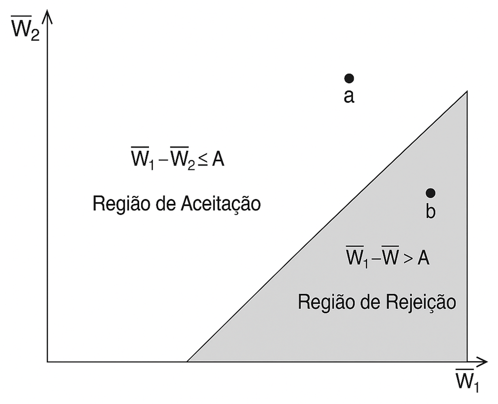

Figura 1: Regiões de Aceitação e Rejeição: Programa de educação infantil. Adaptada de Hansen (2022).

## Teste de Hipóteses

**Exemplo 2: Regiões Crítica e de Aceitação**

- Tomemos agora o exemplo das rotas de ônibus.
- Suponha que você investigue as hipóteses realizando um **experimento**:  
  você pega cada ônibus uma vez e registra o tempo necessário para viajar de casa até a universidade. Seja $X_1$ e $X_2$ os dois tempos de viagem observados.
- Você decide utilizar a seguinte regra de decisão: se a diferença absoluta entre os tempos de viagem for maior que $B$ minutos, você rejeitará a hipótese de que os tempos médios de viagem são iguais; caso contrário, você aceitará a hipótese.
- A região de aceitação ($\overline{C}$) é o conjunto $\overline{C} = \{\, |X_1 - X_2| \leq B \,\}.$
- A região de rejeição é o conjunto $C = \{\, |X_1 - X_2| > B \,\}$
- A Fig. 2 mostra estes conjuntos (ou regiões)

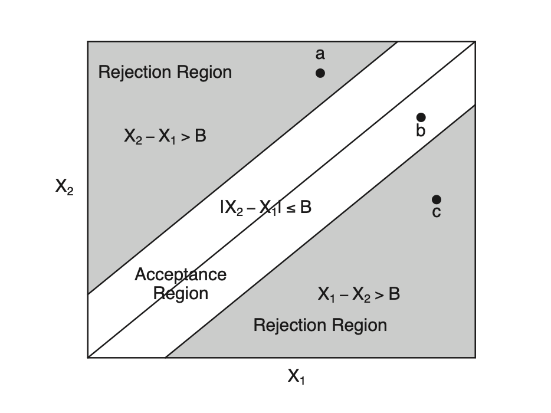

Figura 2: Regiões de Aceitação e Rejeição: Rotas de ônibus. Fonte: Hansen (2022).

Como a hipótese alternativa é bilateral, a região de rejeição é a união de dois subconjuntos disjuntos.

Para ilustrar como as decisões são tomadas, três pares de dados são mostrados:

- O ponto $a$ satisfaz $X_2 - X_1 > B$, portanto, **rejeitamos $H_0$**.
- O ponto $c$ satisfaz $X_1 - X_2 > B$, portanto, também **rejeitamos $H_0$**.
- O ponto $b$ satisfaz $|X_1 - X_2| \leq B$, portanto, **aceitamos $H_0$**.

## Teste de Hipóteses

**Definição Formal de Teste de Hipóteses**

Um teste de hipótese de $H_0$ versus $H_A$ é decisão que pode ser representada por uma função $\varphi:\mathbb{R}^n\to\{0,1\}$, na qual 0 significa não rejeitar $H_0$ e 1 significa rejeitar $H_0$ em favor de $H_1$, da seguinte forma:

$$\begin{align*}
\varphi(x_1,\ldots,x_n)=\begin{cases}
1 & \text{se}\ (x_1,\ldots,x_n)'\in C,\\
0 & \text{se}\ (x_1,\ldots,x_n)'\in \overline{C},
\end{cases}
\end{align*}$$

Onde $C$ e $\overline{C}$ fornecem uma partição do espaço amostral $\mathbb{R}^n$. O conjunto $C$ denota a região **crítica** ou região de rejeição da $H_0$ e $\overline{C}$ é a região de **aceitação** da $H_0$.

- Portanto, um teste de hipótese é **totalmente determinado pela região crítica** $C$.
- Mais precisamente, a regra de decisão em um teste de hipótese é totalmente determinada pela região crítica $C$: ela define **quando rejeitamos ou não** a hipótese nula com base nos dados observados.
- Assim, em princípio, existem infinitos testes para testar uma hipótese, o que exigirá a definição de algum critério para escolher um determinado teste.

## Teste de Hipóteses

**Importância da Região Crítica de um Teste**

- Como vimos, a decisão em um teste de hipótese é **totalmente determinada pela região crítica** $C$: ela define **quando rejeitamos ou não** a hipótese nula com base nos dados observados.
- A princípio, poderíamos tentar determinar essa região crítica diretamente como um subconjunto do espaço amostral $S$.
- Se tivermos uma variável aleatória, isso significaria trabalhar com uma região em $\mathbb{R}$, o que não seria tão difícil.
- Mas, se tivermos um vetor aleatório com dois componentes, precisaríamos determinar a região crítica em $\mathbb{R}^2$; com três componentes, em $\mathbb{R}^3$; e com $n$ componentes, em $\mathbb{R}^n$.
- Isso se torna muito difícil, porque, no caso de variáveis contínuas, precisaríamos calcular **integrais múltiplas** sobre regiões complexas em $\mathbb{R}^n$ — o que, na prática, é quase impossível de fazer manualmente e extremamente custoso computacionalmente quando $n$ é grande.

## Teste de Hipóteses

**Estatística de Teste**

- Embora a região crítica $C$ seja um subconjunto de $\mathbb{R}^n$, é mais simples defini-la indiretamente por meio de uma **estatística de teste**.
- A estatística de teste determina a região de rejeição do teste ($C$).
- Uma forma alternativa de expressar a regra de decisão é construir uma função da amostra, chamada **estatística de teste** $T = T(X_1,\ldots,X_n)$, que define a região crítica $C$.
- **Definição:** Uma estatística de teste para testar $H_0$ versus $H_A$ é uma função da amostra cuja distribuição amostral é conhecida (ou aproximável) sob a suposição de que $H_0$ é verdadeira.
- A expressão “sob $H_0$” indica que a distribuição da estatística de teste é considerada assumindo que a hipótese nula é verdadeira.

## Teste de Hipóteses

**Estatística de Teste**

- A estatística de teste e a região crítica são construídas de modo que $T \in C$ para todas as amostras em $C$ e $T \notin C$ para todas as amostras em $\overline{C}$.
- Para muitos testes, a região crítica pode ser simplificada para um **valor crítico** $c$, onde:
  - $T \leq c$ para todas as amostras em $\overline{C}$.
  - $T > c$ para todas as amostras em $C$.
- Isso é típico da maioria dos testes unilaterais e da maioria dos testes bilaterais de múltiplas hipóteses.
- Testes bilaterais de uma hipótese escalar geralmente assumem a forma $|T| > c$, então a região crítica é $C = {x: |x| > c}$.
- No exemplo do programa de educação infantil, definimos $T = W_1 - W_2$ e $c = A$.
- As regiões de aceitação e rejeição são ilustradas nas figuras 3 e 4.

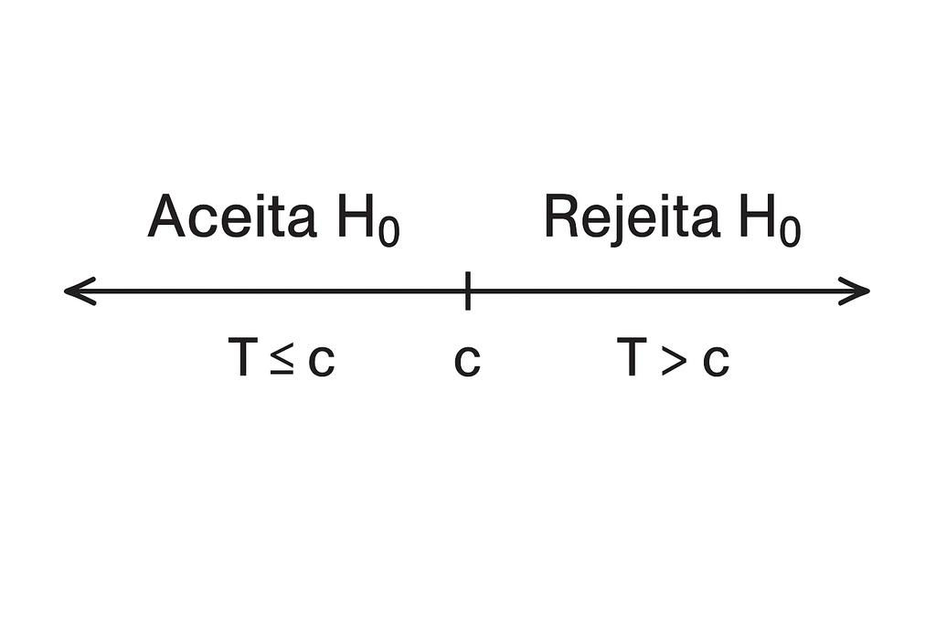

Figura 3: Teste unilateral, Exemplo: $H_A: \theta > 0$.

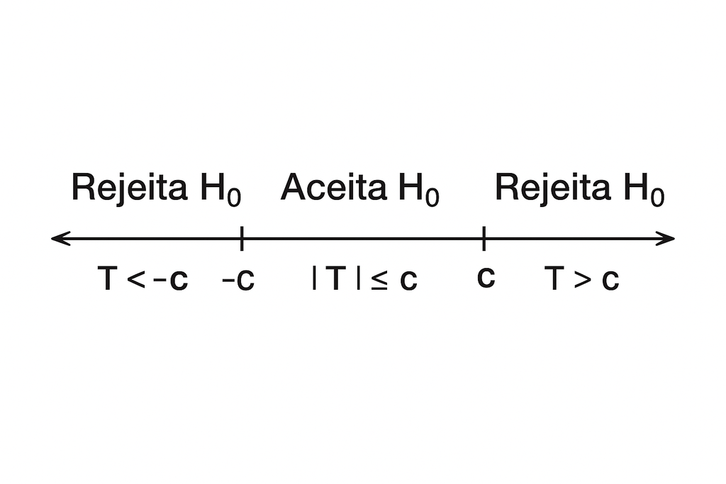

Figura 4: Teste bilateral, Exemplo: $H_A: \theta \neq 0$.

- a Fig. 3 ilustra testes onde a aceitação ocorre para a regra $T \leq c$.
- a Fig. 4 ilustra testes onde a aceitação ocorre para a regra $|T| \leq c$.
- Essas regras dividem o espaço amostral, reduzindo um espaço amostral n-dimensional a uma única dimensão, o que é muito mais fácil de visualizar.

## Teste de Hipóteses

**Como obter uma Estatística de Teste?**

- Uma estatística de teste, em geral, é obtida tomando um estimador do parâmetro desconhecido envolvido em $H_0$ e **transformando-o** de tal forma que tenha uma distribuição amostral conhecida ou aproximável sob $H_0$, por exemplo:

$$\begin{align}
T(X_1,\ldots,X_n)=\frac{\bar{X}-\mu_0}{s/\sqrt{n}}\stackrel{H_0}{\sim} t_{n-1}
\end{align}$$

- $\stackrel{H_0}{\sim}$ significa que a distribuição da estatítica de teste, considerando que hipótese nula seja verdadeira, é uma distribuição $t_{n-1}$.

## Teste de Hipóteses

**Erros em Testes de Hipóteses: Tipo I e Tipo II**

- Uma decisão pode ser correta ou incorreta.
- Uma decisão incorreta é um **erro**.
- Dados os dois estados possíveis do mundo ($H_0$ ou $H_A$) e as duas decisões possíveis (Não Rejeitar $H_0$ ou Rejeitar $H_0$), existem quatro pares possíveis de estados e decisões, conforme ilustrado no próximo slide.

## Erros em Testes de Hipóteses

| Estado do Mundo | Decisão Rejeitar H₀ | Decisão Não Rejeitar H₀ |
| --- | --- | --- |
| H₀ é “verdadeira” | Erro Tipo I | Decisão Correta |
| H₀ é “falsa” | Decisão Correta | Erro Tipo II |

**Erros em Testes de Hipóteses**

- Portanto, existem dois tipos de erros, aos quais os estatísticos deram os nomes de:
- **Erro Tipo I:** rejeitar a $H_0$ quando $H_0$ é “verdadeira”
- **Erro Tipo II:** Aceitar $H_0$ quando $H_0$ é “falsa” (ou $H_A$ é “verdadeira”).

## Erros em Testes de Hipóteses

**Exemplo 1: Programa de Educação Infantil**

- **Erro do Tipo I:** é a decisão incorreta de afirmar que a educação na primeira infância aumenta os salários na vida adulta quando, na realidade, a política não tem efeito algum.
- **Erro do Tipo II:** é a decisão incorreta de afirmar que a educação na primeira infância não aumenta os salários na vida adulta quando, na realidade, ela de fato aumenta os salários.

## Erros em Testes de Hipóteses

**Exemplo 1: Rotas de Ônibus**

- **Erro do Tipo I:** é a decisão incorreta de afirmar que os tempos médios de viagem são diferentes quando, na realidade, eles são iguais.
- **Erro do Tipo II:** é a decisão incorreta de afirmar que os tempos médios de viagem são iguais quando, na realidade, eles são diferentes.

## Erros em Testes de Hipóteses

**Consequências de Erros Tipo I e Tipo II**

Embora ambos os erros representem decisões incorretas, **não são simétricos** e **têm consequências diferentes**.

#### **Exemplo: Educação Infantil**

- **Erro Tipo I:** investir em um programa que **não tem efeito real** → desperdício de recursos públicos (desconsiderando outros benefícios do programa).
- **Erro Tipo II:** **não implementar** um programa que **de fato melhora salários** → perda de benefícios sociais.

#### **Exemplo: Rotas de Ônibus**

- **Erro Tipo I:** evitar uma rota que é, na verdade, equivalente → inconveniência desnecessária.
- **Erro Tipo II:** continuar usando qualquer ônibus mesmo que haja um claramente mais rápido → perda de tempo recorrente.

#### Gravidade do Erro

- A **gravidade do erro** depende da realidade (desconhecida):
  - Se o efeito é pequeno, o erro pode ter baixo custo.
  - Se o efeito é grande, o custo do erro pode ser substancial.

## Erros em Testes de Hipóteses

**Aleatoriedade e a Impossibilidade de Decisão Perfeita**

- Em um mundo **ideal**, poderíamos dividir o espaço amostral em dois conjuntos:
  - Amostras em $\overline{C}$ (região de aceitação) ocorreriam somente se $H_0$ for verdadeira.
  - Amostras em $C$ (região crítica) ocorreriam somente se $H_A$ for verdadeira.
- Nesse caso, bastaria observar os dados para saber com certeza se $H_0$ é verdadeira ou falsa.
- Mas no **mundo real**, isso quase nunca é possível:
- A **aleatoriedade dos fenômenos** significa que sempre há uma **probabilidade não nula de erro**.
- Como eliminar os erros é impossível, Neyman e Pearson voltaram-se ao que era viável: **minimizar a probabilidade de ocorrência de um erro**.

## Erros em Testes de Hipóteses

**Probabilidades de Erros**

- Sabemos que as estatísticas de testes são **variáveis aleatórias**, pois são funções de uma amostra aleatória.
- Assim, podemos medir sua acurácia por meio da probabilidade de que nos levem a tomar uma decisão correta.
- Para isso, usamos a **função poder**, definida a seguir.

## Probabilidades de Erros

**Definição: Função Poder**

A **função poder** indica a probabilidade de rejeitar a hipótese nula $H_0$, dado que a população tem distribuição $F$:

$$\pi(F) = P[\text{Rejeitar } H_0 \mid F] = P[T \in C \mid F]$$

Ou seja, é a chance de que a estatística de teste $T$ caia na região crítica $C$, assumindo que os dados vêm de uma população com distribuição $F$.

## Probabilidades de Erros

**Definição: **Tamanho** de um Teste**

O **tamanho** de um teste é a probabilidade de cometer um Erro Tipo I, ou seja, rejeitar $H_0$, quando $H_0$ é verdadeira:

$$\pi(F_0) = P[\text{Rejeitar } H_0 \mid F_0]$$

Aqui, $F_0$ representa a distribuição populacional quando $H_0$ é verdadeira.

## Probabilidades de Erros

**Definição: **Poder** de um Teste**

O **poder** de um teste de hipóteses é a probabilidade de rejeitar $H_0$ quando $H_0$ é falsa:

$$\pi(F_A) = P[\text{Rejeitar } H_0 \mid F_A] = 1 - P[\text{Aceitar } H_0 \mid F_A]$$

com $F \in H_A$, isto é, para distribuições onde os dados vêm de uma população em que $H_0$ é falsa.

#### Relação com o Erro Tipo II

Se $F \in H_A$, então o **poder** $\pi(F)$ representa a chance de **detectar corretamente que $H_0$ é falsa**.

O **erro Tipo II** é justamente a chance de **não detectar isso**, ou seja:

$$\text{Erro Tipo II} = 1 - \pi(F)$$

Assim, o poder de um teste é o **complemento do erro Tipo II**.

## Probabilidades de Erros

**Resumo**

- O **tamanho** e o **poder** de um teste são calculados a partir da **função poder** $\pi(F)$.
- O **tamanho** do teste é a função poder avaliada sob a hipótese nula $F_0$.
  - isto é, quando os dados vêm de uma população consistente com a hipótese nula.
- O **poder** do teste é a função poder avaliada sob a hipótese alternativa $F_A$
  - isto é, quando os dados vêm de uma população consistente com a hipótese alternativa.

## Probabilidades de Erros

**A Base Probabilística do Tamanho e Poder de Teste**

- Para calcular essas probabilidades, é importante lembrar que a estatística de teste $T$ é uma variável aleatória, ou seja, ela pode assumir diferentes valores a cada nova amostra coletada.
- Por isso, $T$ possui uma **distribuição amostral**, que descreve a probabilidade de $T$ assumir diferentes valores, dependendo da distribuição populacional dos dados.
- Essa distribuição é representada por sua **função de distribuição acumulada**:

$$G(x \mid F) = P[T \leq x]$$

- ou seja, a probabilidade de que $T$ assuma valores menores ou iguais a $x$, quando os dados seguem uma distribuição populacional $F$.
- Como $T$ depende dos dados, sua distribuição muda conforme muda a distribuição da população de onde os dados vêm.

## Probabilidades de Erros

**A Base Probabilística do Tamanho e Poder de Teste**

- Quando assumimos que a hipótese nula é verdadeira, isto é, que a população segue a distribuição $F_0$, obtemos a **distribuição amostral nula**:

$$G_0(x) = G(x \mid F_0)$$

- A função $G_0(x)$ descreve como a estatística de teste $T$ se comporta quando $H_0$ é verdadeira, e é a base para determinar quando um valor de $T$ é considerado “extremo” o suficiente para rejeitar $H_0$.
- É com base nela que escolhemos a **região crítica** do teste (o “limiar de rejeição”) e, portanto, é ela que determina a probabilidade de cometermos um erro Tipo I — o **tamanho** do teste.
- Em resumo: toda a lógica dos testes de hipóteses parte da distribuição amostral da estatística de teste sob $H_0$.

## Probabilidades de Erros

**Teste Unilateral e Função Poder**

Vamos nos focar em testes unilaterais com região de rejeição $T > c$.

Neste caso, a **função poder** tem uma expressão simples, dada por:

$$\pi(F) = P[T > c \mid F] = 1 - P[T \leq c \mid F] = 1 - G(c \mid F)
\tag{1}$$

Onde $G(c \mid F)$ é a função de distribuição acumulada (FDA) () da estatística $T$ sob $F$ (i.e, *distribuição amostral* de $T$).

Se $F_0$ é a distribuição sob a hipótese nula, o **tamanho do teste** é dado por:

$$\pi(F_0) = P[T > c \mid F_0] = 1 - G_0(c)$$

#### Como o valor crítico $c$ afeta os erros

A função $G(c \mid F)$ é **monotonicamente crescente**: à medida que aumentamos $c$, a probabilidade acumulada $G(c \mid F)$ **aumenta**.

Como a função poder é dada por:

$$\pi(F) = 1 - G(c \mid F)$$

então quanto maior o valor crítico $c$, menor será a função poder $\pi(F)$.

Por quê?

- Ao aumentar $c$, estamos tornando a região crítica ($T > c$) **mais difícil de atingir**.
- Isso reduz a chance de rejeitar $H_0$, tanto quando ela é verdadeira quanto quando ela é falsa.

#### Efeitos sobre os erros

- Quando $F = F_0$ (isto é, quando $H_0$ é verdadeira), a função poder $\pi(F_0)$ representa a **probabilidade de erro Tipo I** (ou seja, rejeitar $H_0$ por engano).
  - Como $G_0(c)$ cresce com $c$, temos que $1 - G_0(c)$ **diminui**: o erro Tipo I **diminui** com $c$.
- Quando $F \in H_A$ (isto é, $H_0$ é falsa), a função poder $\pi(F)$ representa a probabilidade de detectar **corretamente** que $H_0$ é falsa.

  Se $\pi(F)$ diminui com $c$, então o erro **Tipo II**, dado por $1 - \pi(F)$, **aumenta**: ⇒ o erro Tipo II aumenta com $c$.
- *Trade-off Fundamental*: reduzir a chance de um erro **aumenta** a chance do outro.
- Como ambas as probabilidades de erro não podem ser simultaneamente reduzidas, algum tipo de **compromisso** precisa ser adotado.

## Abordagem de Neyman-Pearson

**Estratégia Neyman-Pearson**

A abordagem clássica, proposta por **Neyman e Pearson**, consiste em duas etapas:

1. **Controlar o tamanho do teste**: escolher previamente um limite máximo para a probabilidade de cometer um erro Tipo I (rejeitar $H_0$ quando ela é verdadeira);
2. **Minimizar o erro Tipo II**: dentre todos os testes que respeitam esse limite, escolher aquele que torna menor a probabilidade de cometer um erro Tipo II, (não rejeitar $H_0$ quando ela é falsa), o que equivale a escolher o teste com maior poder.
- O teste selecionado com esta estratégia é chamado de **Teste Uniformemente Mais Poderoso** (do inglês *Uniformly Most Powerful*, UMP)

## Abordagem de Neyman-Pearson

**Estratégia Neyman-Pearson**

**Definição:** O **nível de significância** $\alpha \in (0,1)$ é a probabilidade escolhida pelo pesquisador para ser o **tamanho** máximo aceitável do teste. Ou seja, é a probabilide máxima aceitável de cometer um erro Tipo I.

#### Comentários

- Como sabemos, as escolhas tradicionais para níveis de significância são $\alpha = 0,10$, $\alpha = 0,05$ e $\alpha = 0,01$, sendo $\alpha = 0,05$ a mais comum.
- Definir $\alpha = 0,05$, significa que um pesquisador considera aceitável que haja uma chance em 20 de um resultado falso positivo.
- Essa regra prática tem norteado a prática empírica nas ciências sociais (e em diversas outras) há muitos anos.
- Em discussões recentes, no entanto, muitos pesquisadores têm argumentado que um nível de significância muito menor deve ser selecionado, pois os periódicos acadêmicos estão publicando muitos falsos positivos.
- Em particular, foi sugerido que os pesquisadores definam $\alpha = 0,005$ para que um falso positivo ocorra uma vez a cada 200.
- De qualquer forma, não há base puramente científica para a escolha de $\alpha$.

## Abordagem de Neyman-Pearson

**Estratégia Neyman-Pearson - Teste Unilateral**

1. **Seleciona-se o nível de significância** $\alpha$.
2. **Escolhe-se uma estatística de teste 𝑇 e determina-se** **sua distribuição amostral sob** $H_0$.
3. **Determina-se o valor crítico** $c$ para que o teste tenha tamanho **no máximo igual ao nível de significância** $\alpha$.
4. **Calcula-se a estatística de teste** $T$ **com os dados observados**.
5. **Toma-se a decisão comparando** $T$ **com** $c$.

## Abordagem de Neyman-Pearson

**Construção de um Teste Unilateral – Etapas 1 e 2**

Vamos descrever como a abordagem clássica funciona para um teste unilateral:

**1. Seleciona-se o nível de significância**

Seguindo a convenção, vamos ilustrar com $\alpha = 0,05$.

**2. Escolhe-se uma estatística de teste $T$**

E determina-se sua distribuição amostral sob $H_0$, ou seja, como $T$ se comporta quando a hipótese nula é verdadeira.

Por exemplo, suponha que $T$ seja a média amostral $\bar{X}$ de uma variável $X \sim N(\theta, \sigma^2)$.  
Nesse caso, $T \sim N(\theta, \sigma^2/n)$.

Sob $H_0: \theta = \theta_0$, temos:

$$T \sim N\left(\theta_0, \frac{\sigma^2}{n}\right)$$

e sua função de distribuição acumulada (FDA) sob $H_0$ é:

$$G_0(x) = \Phi\left( \frac{x - \theta_0}{\sigma / \sqrt{n}} \right)$$

onde $\Phi$ é a FDA da distribuição normal padrão $N(0,1)$.

## Abordagem de Neyman-Pearson

**Construção de um Teste Unilateral – Etapa 3**

**3. Escolhe-se o valor crítico (c)**

Queremos que o teste tenha **tamanho no máximo igual** ao nível de significância $\alpha$, ou seja:

$$1 - G_0(c) \leq \alpha$$

Isso garante que a probabilidade de $T$ cair na **região crítica** $(T > c)$, sob $H_0$, seja no máximo $\alpha$.

Como $G_0$ é uma função de distribuição acumulada monotonicamente crescente, podemos inverter a inequação usando sua **função quantílica** (a inversa da FDA):

$$c = G_0^{-1}(1 - \alpha)$$

Esse é o valor tal que, sob $H_0$, a probabilidade de observar $T > c$ é exatamente $\alpha$.

**Padronização:**

Para facilitar a análise gráfica e computacional do poder, utilizamos uma forma  
**padronizada** da estatística de teste:

$$T \sim N(\theta, \sigma^2) \quad \Rightarrow \quad \text{sob } H_0: \theta = 0, \quad T \sim N(0, \sigma^2)$$

Nesse caso, a função de distribuição acumulada de $T$ é:

$$G_0(x) = \Phi\left( \frac{x}{\sigma} \right)$$

Essa padronização destaca a razão $\theta / \sigma$, conhecida como **tamanho de efeito padronizado**,  
central na análise do poder e na determinação de tamanhos de amostra.

**Nesse caso, o valor crítico é:**

$$c = \sigma Z_{1-\alpha}$$

onde $Z_{1-\alpha}$ é o quantil ($1 - \alpha$) da distribuição normal padrão.

Por exemplo:

$$Z_{0{,}95} = \texttt{qnorm(0.95)} \approx 1{,}645
\quad \Rightarrow \quad
P(Z \leq 1{,}645) = 0{,}95$$

## Abordagem de Neyman-Pearson

**Construção de um Teste Unilateral - Etapas 4 e 5**

**4. Calcula-se a estatística $T$ com os dados observados.**

**5. Toma-se a decisão**

- Aceita-se $H_0$ se $T \leq c$ e rejeita-se $H_0$ se $T > c$.

## Abordagem de Neyman-Pearson

**Propriedade/Teorema**

Se o valor crítico é escolhido como o quantil $1-\alpha$ da distribuição amostral nula, então o tamanho do teste é igual ao nível de significância escolhido:

$$P(\text{Rejeitar } H_0 \mid F_0) = \alpha$$

Ou seja, o procedimento de Neyman-Pearson **garante por construção** que o teste terá o tamanho desejado.

## Abordagem de Neyman-Pearson

**Teste Unilateral - Distribuição Amostral sob $H_0$**

- A Fig. 5 ilustra uma distribuição amostral nula e a região crítica para um teste com tamanho de 5%.
- A região crítica $T > c$ está sombreada e contém 5% da massa de probabilidade.
- A região de aceitação $T \leq c$ não está sombreada e contém 95% da massa de probabilidade.

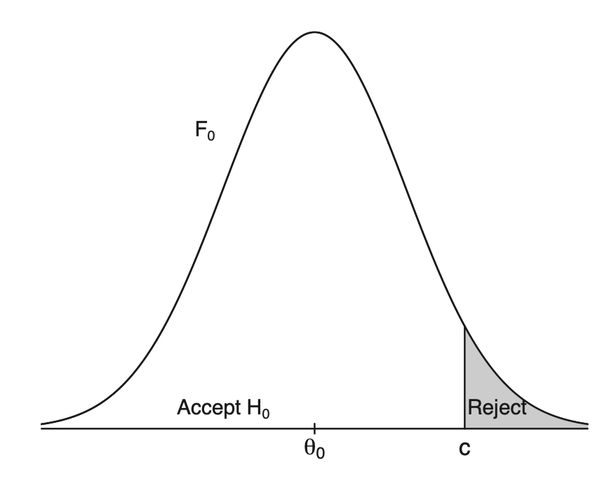

Figura 5: Distribuição amostral sob a hipótese nula para um teste unilateral. A região crítica $T > c$ contém 5% da área total (erro tipo I). Adaptado de Hansen (2022).

## Abordagem de Neyman-Pearson

**Teste Unilateral - Poder do Teste**

**1. Definimos o valor crítico por $\alpha$:**

$$P(T>c\mid F_0)=\alpha
\;\Longleftrightarrow\;
1-G_0(c)=\alpha
\;\Longleftrightarrow\;
c=G_0^{-1}(1-\alpha).$$

**2. Substituímos em $\pi(F)$:**

$$\pi(F)=P(T>c\mid F)=1-G(c\mid F)
=1-G\!\big(G_0^{-1}(1-\alpha)\mid F\big).$$

**3. Caso normal (média igual a $\theta$)**

Sabemos que a estatística $T$ tem FDA:

$$G(x\mid F)=\Phi\!\left(\frac{x-\theta}{\sigma}\right),$$

sendo $\Phi$ a FDA da normal padrão e $\sigma$ é o desvio-padrão de $T$ (por exemplo, $\sigma=\sigma_X/\sqrt{n}$ se $T$ for média amostral de $X$).

Sob $H_0:\theta=0$, $G_0(x)=\Phi(x/\sigma)$ e

$$c = G_0^{-1}(1-\alpha)=\sigma\,Z_{1-\alpha}.$$

Logo,

$$\begin{align*}
\pi(F)
&=1-\Phi\!\left(\frac{\sigma Z_{1-\alpha}-\theta}{\sigma}\right)
=1-\Phi\!\left(Z_{1-\alpha}-\frac{\theta}{\sigma}\right).
\end{align*}$$

**Monotonicidade:**

- Para $\alpha$ fixo, defina $z^\ast=Z_{1-\alpha}-\theta/\sigma$.
- Como $\Phi$ é crescente, $\uparrow \theta/\sigma \Rightarrow \downarrow z^\ast \Rightarrow \downarrow \Phi(z^\ast) \Rightarrow \uparrow \pi(F)=1-\Phi(z^\ast).$
- Assim, $\pi(F)$ é **monotonicamente crescente** em $\theta/\sigma$.

**Interpretação:**

Quanto maior o efeito ($\theta$) e/ou menor a variabilidade/ruído ($\sigma$) $\Rightarrow$ maior o poder.

## Abordagem de Neyman-Pearson

**Teste Unilateral – Poder do Teste**

**1. Definimos o valor crítico com base em $\alpha$:**

$$P(T > c \mid F_0) = \alpha
\;\Longleftrightarrow\;
1 - G_0(c) = \alpha
\;\Longleftrightarrow\;
c = G_0^{-1}(1 - \alpha)$$

**2. Substituímos em $\pi(F)$:**

A função poder é a probabilidade de rejeitar $H_0$ quando $H_A$ é verdadeira:

$$\pi(F) = P(T > c \mid F) = 1 - G(c \mid F), \quad \text{com } c = G_0^{-1}(1 - \alpha)$$

Logo:

$$\pi(F) = 1 - G\big(G_0^{-1}(1 - \alpha) \mid F\big)$$

**3. Caso normal:** $T \sim N(\theta, \sigma^2)$

A estatística de teste $T$ tem função de distribuição acumulada:

$$G(x \mid F) = \Phi\left(\frac{x - \theta}{\sigma}\right)$$

com $\Phi$ sendo a CDF da normal padrão, e $\sigma$ o desvio-padrão de $T$  
(por exemplo, $\sigma = \sigma_X / \sqrt{n}$ se $T$ for uma média amostral).

Sob $H_0 : \theta = 0$, temos:

$$G_0(x) = \Phi\left( \frac{x}{\sigma} \right)
\quad \Rightarrow \quad
c = \sigma Z_{1 - \alpha}$$

Substituindo, obtemos:

$$\begin{align*}
\pi(F)
&= 1 - \Phi\left( \frac{c - \theta}{\sigma} \right)
= 1 - \Phi\left( \frac{\sigma Z_{1-\alpha} - \theta}{\sigma} \right) \\
&= 1 - \Phi\left( Z_{1-\alpha} - \frac{\theta}{\sigma} \right)
\end{align*}$$

**Monotonicidade:**

- Para $\alpha$ fixo, defina $z^\ast = Z_{1-\alpha} - \theta/\sigma$
- Como $\Phi$ é crescente:

$$\uparrow \theta/\sigma \;\Rightarrow\; \downarrow z^\ast
\;\Rightarrow\; \downarrow \Phi(z^\ast)
\;\Rightarrow\; \uparrow \pi(F) = 1 - \Phi(z^\ast)$$

Ou seja, $\pi(F)$ é **monotonicamente crescente** em $\theta/\sigma$

## Abordagem de Neyman-Pearson

**Teste Unilateral - Distribuição Amostral sob $H_A$**

A expressão anterior para o poder do teste corresponde, graficamente, à probabilidade de a estatística de teste cair na região crítica quando os dados vêm de uma distribuição alternativa $F_A$.

A Fig. 6 mostra exatamente isso:

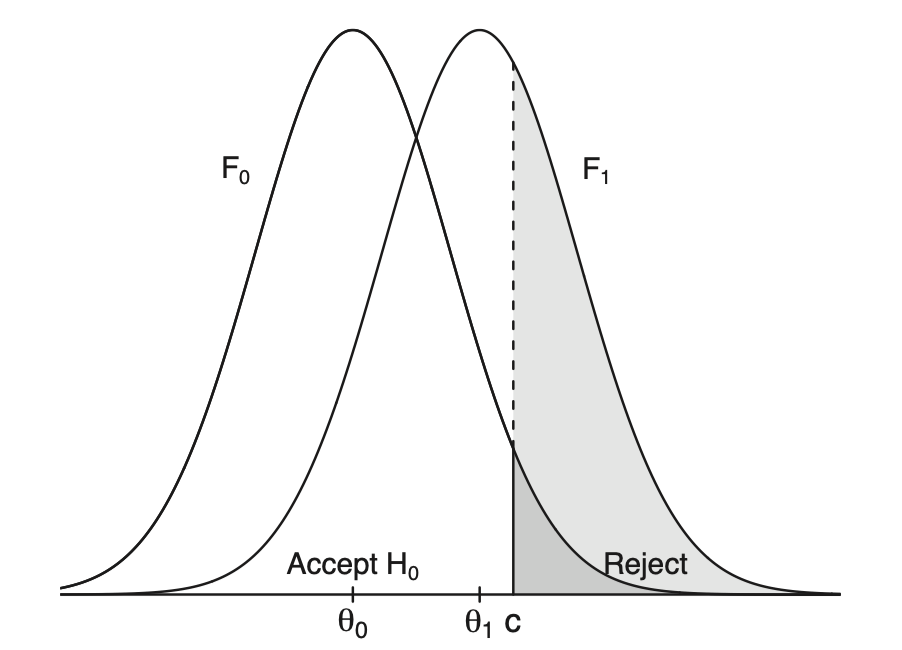

Figura 6: Distribuições sob $H_0$ ($F_0$) e $H_1$ ($F_1$ = $F_A$), com região crítica à direita de $c$. A área escura representa o erro tipo I; a área total sombreada sob $F_1$ representa o poder do teste (37%). Adaptado de Hansen (2022).

- A curva marcada como “$F_0$” é a distribuição de $T$ sob a hipótese nula.
- A curva marcada como “$F_1$” é a distribuição de $T$ sob a hipótese alternativa.
- A parte sombreada sob $F_0$ corresponde ao erro Tipo I (5%).
- A parte sombreada sob $F_1$ corresponde ao poder do teste para $\theta_1$ (37%).

Isso significa que, para essa alternativa particular $\theta_1$, o poder do teste é 37%, ou seja, o poder é um pouco maior de uma chance em três de rejeitar $H_0$.

## Função Poder do Teste Unilateral

**Exemplo Numérico**

A fórmula do poder para o caso normal é:

$$\pi(F) = 1 - \Phi\!\left(Z_{1-\alpha} - \frac{\theta}{\sigma}\right).$$

Com $\alpha = 0,05$, temos $Z_{1-\alpha} = Z_{0,95} \approx 1,645$.

Escolhendo uma alternativa com $\theta/\sigma \approx 1,313$, obtemos:

$$\pi(F) = 1 - \Phi(1,645 - 1,313)
= 1 - \Phi(0,332)
\approx 1 - 0,630
= 0,37.$$

Ou seja, o poder do teste é de aproximadamente 37%.

**Código em R:**

```r
alpha <- 0.05
z <- qnorm(1 - alpha)
z
```

```
[1] 1.6449
```

```r
theta_sobre_sigma <- 1.313
poder <- 1 - pnorm(z - theta_sobre_sigma)
poder
```

```
[1] 0.37
```

## Função Poder do Teste Unilateral

**Atividade com o Aplicativo Shiny**

- Acesse: [washington-silva.shinyapps.io/funcao_poder](https://washington-silva.shinyapps.io/funcao_poder/)
- Use a aba **“Distribuições (H0 vs H1)”** e mantenha a opção **“Cauda direita (T > c)”**.
1. **Mantenha** $\alpha = 0,05$.
- Ajuste $\theta/\sigma$ até obter **poder** $\approx$ 0,80.
- Anote os valores exibidos em **“Números”**: $\theta/\sigma$, $Z_{1-\alpha}$, $c$, poder, $\beta = 1 - \text{poder}$.
2. Mantenha o $\theta/\sigma$ do passo anterior. <>
- Compare o poder para $\alpha = 0,10$ e $\alpha = 0,01$.
3. **Questão:** Como a mudança de $\alpha$ afetou o valor crítico $c$, e com isso, o poder?

## Teste t

**Populações Normais**

- Falamos sobre testes em geral, mas não fomos especificos sobre como delinear um teste.
- A estatística de teste mais comum usada em aplicações é o teste t.

#### Teorema

No modelo de amostragem normal $X \sim N(\mu, \sigma^2)$:

1. O teste t de $H_0: \mu = \mu_0$ contra $H_A: \mu > \mu_0$ rejeita $H_0$ se $T > q_{1 - \alpha}$, sendo $q_{1 - \alpha}$ o quantil $(1 - \alpha)$ da distribuição $t_{n-1}$.
2. O teste t de $H_0: \mu = \mu_0$ contra $H_A: \mu < \mu_0$ rejeita $H_0$ se $T < q_{\alpha}$.
3. O teste t de $H_0: \mu = \mu_0$ contra $H_A: \mu \neq \mu_0$ rejeita $H_0$ se $|T| > q_{1 - \alpha/2}$.

Estes testes tem tamanho exato $\alpha$.

## Teste t

**Lógica da Prova do Teorema**

Seja $\mu = \mathbb{E}[X]$ e considere a hipótese $H_0 : \mu = \mu_0$. A estatística $t$ para $H_0$ é dada por

$$T = \frac{\overline{X}_n - \mu_0}{s / \sqrt{n}},$$

onde $\overline{X}_n$ é a média amostral e $s^2$ é a variância amostral.

A decisão depende da hipótese alternativa.

- Para a alternativa unilateral $H_1 : \mu > \mu_0$, o teste rejeita $H_0$ em favor de $H_1$ se $T > c$, para algum valor crítico $c$.
- Para a alternativa unilateral $H_1 : \mu < \mu_0$, o teste rejeita $H_0$ em favor de $H_1$ se $T < c$.
- Para a alternativa bilateral $H_1 : \mu \neq \mu_0$, o teste rejeita $H_0$ em favor de $H_1$ se $|T| > c$, ou, de forma equivalente, se $T^2 > c^2$.

Se a variância $\sigma^2$ for conhecida, ela pode ser substituída na fórmula de $T$. Nesse caso, alguns livros didáticos chamam $T$ de estatística $z$.

Há formas alternativas, mas equivalentes, de escrever o teste.

Por exemplo, podemos definir a estatística como $T = \overline{X}_n$ e rejeitar em favor de $\mu > \mu_0$ se

$$T > \mu_0 + c \frac{s}{\sqrt{n}}.$$

É desejável selecionar o valor crítico de forma a controlar o tamanho do teste.

Isso exige que conheçamos a distribuição nula amostral $G_0(x)$ da estatística $T$.

Isso é possível no modelo amostral normal. Isto é, quando $X \sim N(\mu, \sigma^2)$, a distribuição exata $G_0(x)$ de $T$ é a distribuição $t$ de Student com $n-1$ graus de liberdade.

Consideremos o teste contra $H_1 : \mu > \mu_0$. Como descrito em slides anteriores, para um nível de significância $\alpha$ dado, o objetivo é encontrar $c$ tal que

$$1 - G_0(c) \leq \alpha,$$

cuja solução é o quantil $1-\alpha$ da distribuição $t$ de Student com $n-1$ graus de liberdade.

De forma análoga, o teste contra $H_1 : \mu < \mu_0$ rejeita se $T < q_\alpha$.

Agora, consideremos um teste bilateral. Como já descrito, o objetivo é encontrar $c$ tal que

$$2,(1 - G_0(c)) \leq \alpha,$$

cuja solução é

$$c = G_0^{-1}(1 - \alpha/2) = q_{1-\alpha/2}.$$

O teste rejeita se $|T| > q_{1-\alpha/2}$.

## Testes para Populações Normais

**Exercício Resolvido**

**Dados.** Oito projéteis produzidos com uma nova pólvora tiveram velocidades iniciais (m/s): `910, 921, 918, 896, 909, 905, 895, 903`.

**Afirmação do fabricante.** A nova pólvora produz velocidade média acima de 915 m/s.

**Questão 1** A amostra **fornece evidência contra** essa afirmação ao nível de significância $alpha=0,025$?

Assuma $X \sim N(\mu,\sigma^2)$ com $\sigma^2$ desconhecida.

**Hipóteses.**

$$H_0:\ \mu = 915 \\
H_A:\ \mu < 915$$

**Estatística de teste T**

Sabemos que, nesse caso, a distribuição amostral de $T$ sob $H_0$ é:

$$T = \frac{\bar X-\mu_0}{S/\sqrt{n}} \stackrel{H_0}{\sim}; t_{n-1},$$

com (S) o desvio-padrão amostral (denominador (n-1)).

**Região crítica (teste unilateral à esquerda).**

$$C = T < q_{\alpha} \rightarrow T < t_{n-1;\alpha}$$

**Cálculo Manual em R**

```r
x <- c(910, 921, 918, 896, 909, 905, 895, 903)
n  <- length(x)
xb <- mean(x)
s  <- sd(x)          # desvio-padrão amostral (n-1 no denominador)
t_obs <- (xb - 915)/(s/sqrt(n))
alpha <- 0.025
crit  <- qt(alpha, df = n - 1)   # t_{7;0.025} (valor crítico à esquerda)
# valor-p  <- pt(t_obs, df = n - 1)   # valor-p unilateral à esquerda

# lista para exibir os resultados
list(n = n, media = xb, desvio = s, t_observado = t_obs,
     t_critico_esquerda = crit)
```

```
$n
[1] 8

$media
[1] 907.12

$desvio
[1] 9.3723

$t_observado
[1] -2.3766

$t_critico_esquerda
[1] -2.3646
```

**Valores (aprox.).** $\bar X = 907,12$, $s \approx 9,3723$, $t_{\text{obs}} \approx -2,37$, $t_{7;0,025} \approx -2,365$.

**Decisão:** Como $t_{\text{observado}} < t_{7;0,025}$ **rejeita-se** $H_0$.

**Conclusão:** Essa amostra fornece evidência estatística contra a alegação do fabricante de que a velocidade média é superior a 915 m/s ao nível $\alpha = 2,5%$.

**Questão 2:** Resolva a questão usando a função `t.test` de R.

## Teste da Razão de Verossimilhança

**Descrição**

- A **função de verossimilhança** $L_n(\theta)$ mede a compatibilidade entre um valor do parâmetro $\theta$ e os dados amostrados.
- Como o estimador de máxima verossimilhança $\hat{\theta}$ maximiza essa função, é natural utilizá-la para comparar hipóteses pontuais.
- O teste da **razão de verossimilhanças** compara a plausibilidade de duas hipóteses simples, avaliando quão bem cada uma explica os dados observados.

#### Hipóteses Simples

- Considere as hipóteses simples: $H_0: \theta = \theta_0$ e $H_1: \theta = \theta_1$. As verossimilhanças correspondentes são $L_n(\theta_0)$ e $L_n(\theta_1)$.
- A estatística de teste é dada pela **razão de verossimilhanças**:

$$\lambda_n = \frac{L_n(\theta_1)}{L_n(\theta_0)}.$$

- A hipótese nula é **rejeitada** quando essa razão excede um limiar $c$:

$$\lambda_n > c.$$

- Como é comum trabalhar com a **log-verossimilhança**, tomamos o logaritmo da razão:

$$\log \lambda_n = l_n(\theta_1) - l_n(\theta_0),$$

onde $l_n(\cdot)$ denota a log-verossimilhança.

- Por convenção histórica e para permitir o uso de aproximações assintóticas com a distribuição qui-quadrado, é usual multiplicar essa diferença por 2. Assim, definimos a **estatística da razão de verossimilhança** como:

$$\log \lambda_n = 2 \big(l_n(\theta_1) - l_n(\theta_0)\big).$$

- A regra de decisão do teste é: **Aceita-se $H_0$** se $LR_n \leq c$, **Rejeita-se $H_0$** se $LR_n > c$.

## Teste da Razão de Verossimilhança

**Descrição**

- Quando a hipótese alternativa é bilateral, $H_A: \theta \neq \theta_0$, o teste da razão de verossimilhança compara a plausibilidade de $\theta_0$ com a melhor explicação possível para os dados: o valor de $\theta$ que **maximiza** a log-verossimilhança **sem restrições** — o chamado **máximo irrestrito**.

#### Hipótese Alternativa Bilateral

- Seja $\hat{\theta}$ o estimador de máxima verossimilhança (EMV), que satisfaz:

$$\hat{\theta} = \arg\max_{\theta} \, l_n(\theta).$$

- A estatística de teste compara $l_n(\hat{\theta})$, a log-verossimilhança maximizada livremente, com $l_n(\theta_0)$, a log-verossimilhança sob $H_0$:

$$LR_n = 2 \big( l_n(\hat{\theta}) - l_n(\theta_0) \big).$$

- Essa diferença quantifica a perda de ajuste ao restringir $\theta$ em $\theta_0$ em vez de estimá-lo livremente.
- A regra de decisão do teste é: **Aceitar $H_0$** se $LR_n \leq c$, **Rejeitar $H_0$** se $LR_n > c$.
- Para ilustrar, a Fig. 7 apresenta uma função de log-verossimilhança exponencial juntamente com um valor hipotético $\theta_0$ e o EMV $\hat{\theta}$.
- A estatística da razão de verossimilhança é duas vezes a diferença entre a log-verossimilhança nos dois valores.
- O teste da razão de verossimilhança rejeita a hipótese nula se essa diferença for suficientemente grande.

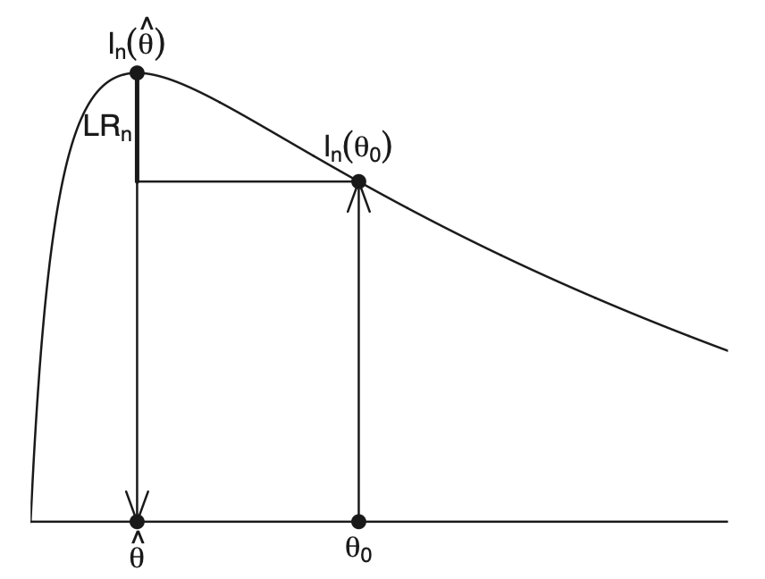

Figura 7: Razão de Verossimilhanças

## Teste da Razão de Verossimilhança

**Exercício**

Um sindicato registra o número de reclamações que são preenchidas por semana pelos trabalhadores de dois turnos diferentes na linha de produção de uma fábrica. O sindicato coletou $n_1=87$ e $n_2=61$ observações independentes sobre o número de reclamações para ambos os turnos $X_1$ e $X_2$, as quais produzem as médias $\bar{x}_1 = 20$ e $\bar{x}_2 = 22$.

Suponha que o número de reclamações por semana do k-ésimo turno tenha uma distribuição $Poisson(\theta_k)$, com $k = 1, 2$. O sindicato quer testar se o número médio de reclamações por semana de ambos os turnos é significativamente diferente ou não com um nível de significância $\alpha = 0,01$. A hipótese a ser testada é:

$$\begin{align*}
H_0&:\theta_1 = \theta_2 \quad \\
H_A&:\theta_1 \neq \theta_2
\end{align*}$$

Utilize um teste da razão de verossimilhanças para responder à questão colocada pelo sindicato.

## Teste da Razão de Verossimilhança

**Teorema de Wilks**

Sob certas condições de regularidade sobre a distribuição $F$ de $X$, e sob $H_0$ simples, tem-se que:

$$-2\log\lambda_n\stackrel{d}{\longrightarrow} \chi_p^2,$$

Ou seja, a estatística da razão de verossimilhanças tem como distribuição assintótica, uma distribuição $\chi^2$ com $p$ graus de liberdade.

#### Testes assintóticos em econometria

- Muitos procedimentos aplicados em econometria são **assintóticos** e baseados em máxima verossimilhança.
- Sua validade depende de resultados de grande amostra, como o Teorema de Wilks.
- Testes da **Razão de Verossimilhança**, Testes de **Wald** e Testes do **Multiplicador de Lagrange** são **métodos** distintos de construir testes a partir da função de verossimilhança.
- Cada método se baseia em uma representação diferente das restrições impostas pelo modelo:
  - Razão de Verossimilhança compara verossimilhanças restrita e irrestrita.
  - Wald testa diretamente se o estimador satisfaz as restrições.
  - Lagrange Multiplier usa as condições de primeira ordem do problema de máxima verossimilhança.
- Em grandes amostras, todos resultam em estatísticas de teste com distribuição qui-quadrado e levam a conclusões equivalentes.

## Lema de Neyman-Pearson

**Teorema**

#### Versão Textual

Entre todos os testes de uma hipótese nula simples contra uma hipótese alternativa simples, com tamanho $\alpha$, o teste da razão de verossimilhança possui o maior poder.

**Nota:** O Lema de Neyman-Pearson é um resultado fundacional na teoria dos testes de hipóteses.

#### Versão Formal

Sejam $H_0: \theta = \theta_0$ (hipótese nula simples) e $H_A: \theta = \theta_A$ (hipótese alternativa simples) e $X = (X_1,\dots,X_n)$ uma amostra aleatória com densidade (ou função de probabilidade) $f(x;\theta)$.

Defina a razão de verossimilhanças:

$$\Lambda(x) = \frac{f(x;\theta_A)}{f(x;\theta_0)}.$$

Então, para um dado nível de significância $\alpha$, o teste de maior poder rejeita $H_0$ sempre que $\Lambda(x) > c$, com $c$ escolhidos de modo que o teste tenha tamanho $\alpha$.

Esse teste é o teste mais poderoso de nível $\alpha$ para $H_0$ contra $H_1$.

## O que “Aceitar $H_0$” significa sobre $H_0$?

**Muito Importante**

- **Spoiler:** a decisão *“Não rejeitar $H_0$”* não significa que $H_0$ seja verdadeira.
- A abordagem clássica prioriza o **controle do erro do Tipo I**.
- Isso significa que exigimos **fortes evidências** para rejeitar $H_0$.
- O **nível de significância** é a probabilidade do erro Tipo I, em geral $\alpha = 0,05$, um valor pequeno.
- A continuidade da **função poder** implica que o poder é pequeno (próximo de $0,05$) para alternativas próximas à hipótese nula.
- O poder também pode ser pequeno para alternativas distantes da hipótese nula quando a quantidade de informação nos dados é limitada.
- Suponha que o poder de um teste seja 25%. Isso significa que, em 3 de cada 4 amostras, o teste **não rejeita $H_0$**, mesmo quando $H_0$ é falsa e a hipótese alternativa $H_A$ é verdadeira.
- Se o poder for 50%, a chance de rejeitar $H_0$ equivale a um **lançamento de moeda**.
- Mesmo que o poder seja 80%, ainda há $20%$ de probabilidade de não rejeitar $H_0$.
- A conclusão é: **não rejeitar $H_0$ não significa que $H_0$ seja verdadeira**. É mais preciso dizer *“falhou em rejeitar $H_0$”* em vez de *“aceitou $H_0$”*.
- Alguns autores adotam essa convenção. O mais importante é ser claro quanto ao significado do teste estatístico.
- Considere o exemplo da **educação infantil**. Se testamos a hipótese $H_0: \theta = 0$, estamos buscando evidências de que o programa teve um efeito positivo sobre os salários na vida adulta.
- Suponha que **não rejeitamos $H_0$** com base na amostra. Isso pode ocorrer por vários motivos:
  - Pode ser que de fato **não exista efeito** do programa sobre os salários.
  - Pode ser que o efeito exista, mas seja **pequeno em relação à variabilidade** dos salários na população.
  - Pode ser que o **tamanho da amostra** seja insuficiente para medir o efeito com precisão.
- Todas essas são possibilidades válidas, e não sabemos qual delas é verdadeira sem mais informações.
- Se a estatística de teste não rejeita $H_0: \theta = 0$, é categoricamente **incorreto** afirmar: *“As evidências mostram que a educação infantil não tem efeito sobre os salários.”*
- O que se pode afirmar é: *“O estudo não encontrou evidências de que existe efeito sobre os salários.”*
- Mais informações podem ser obtidas por meio da análise de um **intervalo de confiança** para $\theta$.

## Significância Estatística

**Muito Importante**

- Quando $\theta$ representa uma magnitude ou efeito importante, muitas vezes é de interesse testar a hipótese de ausência de efeito, ou seja:

$$H_0 : \theta = 0.$$

## Valor-p

**Muito Importante**

## Minicurso Intensivo: Teoria da Probabilidade e Inferência Estatística

**Conteúdo**

- **Fundamentos de probabilidade**: Introdução do conceito e discussão sobre espaços amostrais, eventos independentes, probabilidades condicionais, probabilidade total e a Regra de Bayes.
- **Variáveis aleatórias**: Definição de variável aleatória, formas de representar distribuições (função de probabilidade, função densidade de probabilidade, função de distribuição acumulada).
- **Funções de variáveis aleatórias**: Apresentação de estratégias básicas e diversos exemplos importantes.
- **Momentos**: Definição de momentos de distribuições e estudo de várias técnicas e propriedades para calcular momentos de funções de variáveis aleatórias.
- **Distribuições**: Binomial, hipergeométrica, geométrica, binomial negativa, Poisson, uniforme, beta e normal.
- **Estimação**: Discussão geral e análise da média amostral, critérios de avaliação de estimadores, métodos de estimação: métodos dos momentos e da máxima verossimilhança.
- **Inferência estatística**: Teoria básica sobre intervalos de confiança e testes de hipóteses.

## Referências

BICKEL, P. J.; DOKSUM, K. A. **Mathematical Statistics: Basic Ideas and Selected Topics, Volume I**. 2nd. ed. [s.l.] Chapman & Hall/CRC, 2015.

CASELLA, G.; BERGER, R. L. **Statistical Inference**. 2nd. ed. Pacific Grove, CA: Duxbury Press, 2002.

HANSEM, B. E. **Probability and Statistics for Economists**. Princeton, NJ: Princeton University Press, 2022.

LEHMANN, E. L.; ROMANO, J. P. **[Testing Statistical Hypotheses](https://doi.org/10.1007/0-387-27605-X)**. 3rd. ed. New York: Springer, 2005.